# Week 9: Predicting Recidivism

Ken Steif

November 7, 2018

**Due: Friday, November 30th**

## 1. Introduction

In mid-2016, ProPublica [published](https://www.propublica.org/article/machine-bias-risk-assessments-in-criminal-sentencing) an analysis of a machine learning tool built by a company called Northpointe to assess the “rehabilitation needs” of Broward County, Florida inmates. The main analytic is a predictive ‘risk score’ that gives the propensity of an inmate to commit another crime when released. This phenomenon is referred to as ‘recidivism’. In a [follow-up piece](https://www.propublica.org/article/bias-in-criminal-risk-scores-is-mathematically-inevitable-researchers-say), ProPublica asked how it could be possible that an algorithm is could be *simultaneously fair and unfair*? In this homework, you will address this question.

In terms that we have used this semester, you will investigate whether **the algorithm is not appropriately able to balance accuracy and generalizability**.

From a public policy standpoint, the question is whether we should use decision-making algorithms to guide important resource allocation decisions when those algorithms are biased. There are arguments to be made for and against depending on the use case at hand.

There are likely two inter-related reasons why these algorithms could be biased. First, it could be that the algorithm is underfit - meaning there is not enough predictive power to generate a useful predictions. Perhaps the criminal justice data mined for these algorithms should be integrated with education outcomes, employment history etc.

Second, systematic overpolicing of one group relative to another could translate to disproportionately more arrests of that group. This ‘selection bias’ would appear in the data used to train the algorithm which would effectively bake bias directly into the model and its predictions. One could refer to this in the context of overfitting, but I think it does the topic a disservice by reducing an important societal issue to an engineering connundrum.

Both likely play a role in algorithmic bias, and while we can’t pinpoint the exact contribution of either, we can develop some simple indicators to see how well the model generalizes to inmates across racial groups. That is what you will do today.

*The methodological approach*

Using the open data provided by [Propublica](https://github.com/propublica/compas-analysis), our goal is not to evaluate the original Northpointe algorithm (which is not public), but to use the data to estimate a similar model which we can use to demonstrate our accuracy/generalizability metrics.

*The deliverable:*

For this homework, you will be *making recommendations* to the Mayor about whether or not she should adopt this algorithm in to how the City makes decisions on who gets access to an ex-offender, job training program. The concern is that it is not the best use of our limited job training resources if they are expended on someone who finds him or herself back in jail. Your submission should be a memo to the Mayor that is **no shorter than 500 words and no longer than 700 words**. In it, you will develop the following plots and address the following questions.

- **Exploratory analysis:**
  - Build a plot that visualizes the rate of recidivism by race.
  - What does this plot tell you about the rates of recidivism across different racial groups?
- **Evaluate accuracy: Describe whether or not race should be included in public algorithms.**
  - What is the benefit of using race in the model?
  - Should we institute a blanket rule, that all criminal justice predictive models be estimated without race?
  - Are our models equally accurate across different racial groups?
- **Evaluate bias: Describe whether or not the model generalizes to different racial groups.**
  - Build a facetted barplot where the leftmost plot shows *observed* recidivism rates by race for African Americans, Whites and Hispanics. On the rightmost plot, show predictied recidivism rates by the same race groups. Interpret this plot with respect to race.
  - Interpret the confusion matrix by racial group plot. What should we be concerned with here? Remember who your audience is. Put it in Mayorial terms.
  - Interpret the confusion matrix/accuracy by race table. Tell me about the trade-off between accuracy and generalizability as it relates the *the use* of this algorithm in prioritizing a job training program.
  - Would you recommend the Mayor adopt this algorithm?
- **Extra credit**
  - On a page separate from the memo, can you develop a way to optimize the threshold to create a more equitable distribution of errors?

## 2. Load data and exploratory analysis

Below we load the needed packages, a `plotTheme` and a set of custom color palettes.

```r
options(dplyr.width = Inf)

library(tidyverse)
library(ggalluvial)
library(ModelMetrics)
library(caret)
library(plotROC)
library(knitr)
library(kableExtra)
library(grid)
library(gridExtra)

plotTheme <- function(base_size = 12) {
  theme(
    text = element_text( color = "black"),
    plot.title = element_text(size = 14,colour = "black"),
    plot.subtitle = element_text(face="italic"),
    plot.caption = element_text(hjust=0),
    axis.ticks = element_blank(),
    panel.background = element_blank(),
    panel.grid.major = element_line("grey80", size = 0.1),
    panel.grid.minor = element_blank(),
    panel.border = element_rect(colour = "black", fill=NA, size=2),
    strip.background = element_rect(fill = "grey80", color = "white"),
    strip.text = element_text(size=12),
    axis.title = element_text(size=12),
    axis.text = element_text(size=10),
    plot.background = element_blank(),
    legend.background = element_blank(),
    legend.title = element_text(colour = "black", face = "italic"),
    legend.text = element_text(colour = "black", face = "italic"),
    strip.text.x = element_text(size = 14)
  )
}

palette_9_colors <- c("#0DA3A0","#2999A9","#458FB2","#6285BB","#7E7CC4","#9A72CD","#B768D6","#D35EDF","#F055E9")
palette_8_colors <- c("#0DA3A0","#2D97AA","#4D8CB4","#6E81BF","#8E76C9","#AF6BD4","#CF60DE","#F055E9")
palette_7_colors <- c("#2D97AA","#4D8CB4","#6E81BF","#8E76C9","#AF6BD4","#CF60DE","#F055E9")
palette_5_colors <- c("#2D97AA","#6E81BF","#8E76C9","#AF6BD4","#F055E9")
palette_3_colors <- c("#0DA3A0","#7E7CC4","#F055E9")
palette_2_colors <- c("#0DA3A0","#F055E9")
palette_1_colors <- c("#0DA3A0")
```

This analysis uses data on 6,163 inmates in Broward County. Of those, 2,801 are listed as having a recidivism event. 51% of the inmates are African American and 81% are males.

The data includes a host of justice-oriented variables such as an inmate’s criminal charges - both original and recidivated, and the number of prior charges both as a juvenile and adult. The data also includes a limited set of demographic features including sex, age and race. Noticable omissions are other measures of social, emotional and economic wellbeing that might be able to tell a more nuanced criminological story.

We load the data and do some data wrangling. Unfortunately, this data did not come with a data dictionary. I think many of the variables are self-explanatory. In the code block below, we wrangle features that will be helpful for your analysis and select a final subset.

```r
raw_data <- read.csv("https://raw.githubusercontent.com/propublica/compas-analysis/master/compas-scores-two-years.csv")

df <-
  raw_data %>%
  filter(days_b_screening_arrest <= 30) %>%
  filter(days_b_screening_arrest >= -30) %>%
  filter(is_recid != -1) %>%
  filter(c_charge_degree != "O") %>%
  filter(priors_count != "36") %>%
  filter(priors_count != "25") %>%
  mutate(length_of_stay = as.numeric(as.Date(c_jail_out) - as.Date(c_jail_in)),
         priors_count = as.factor(priors_count),
         Recidivated = as.factor(ifelse(two_year_recid == 1,"Recidivate","notRecidivate"))
         ) %>%
  select(sex,age,age_cat,race,priors_count,two_year_recid,r_charge_desc,
         c_charge_desc,c_charge_degree,r_charge_degree,juv_other_count,
         length_of_stay,priors_count,Recidivated)
```

Below we visualize the frequency of initial charges for each inmate.

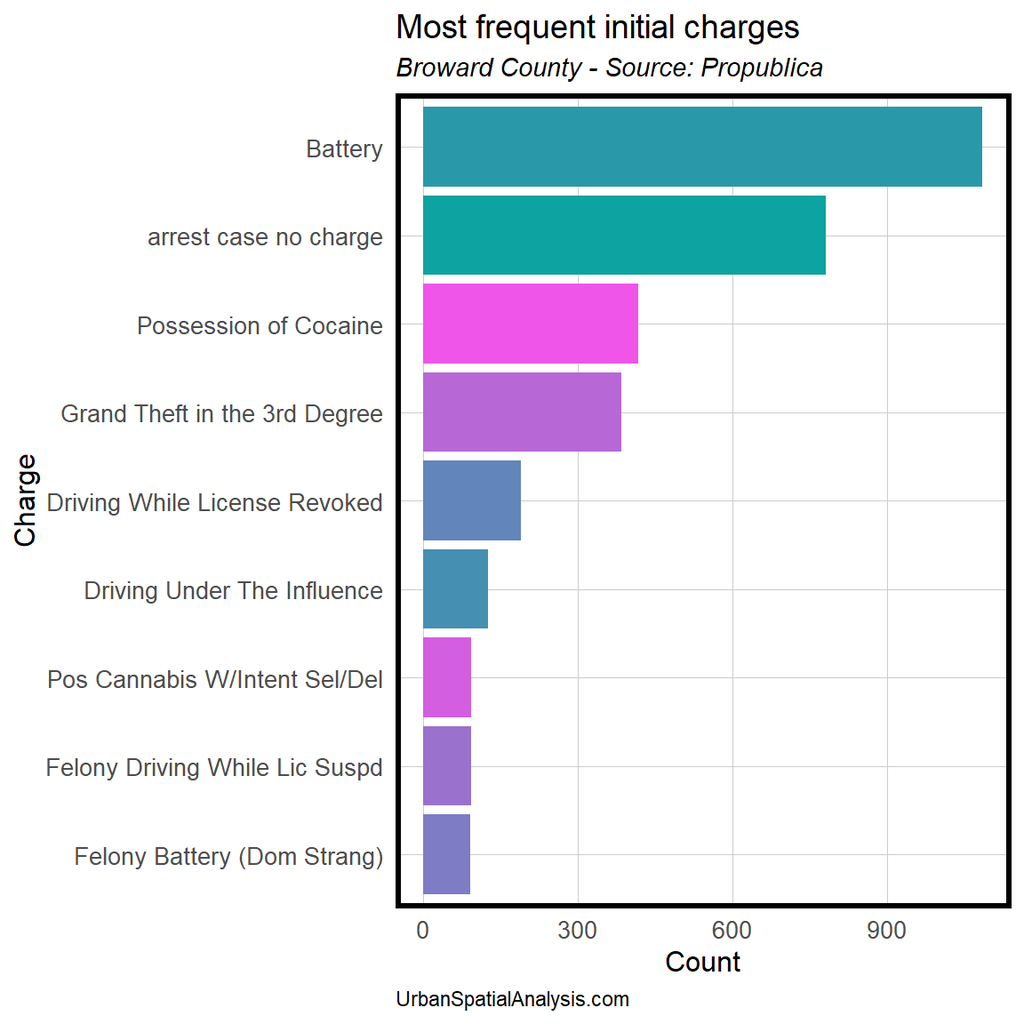

```r
df %>%
  group_by(c_charge_desc) %>%
  summarize(count = n()) %>%
  arrange(-count) %>%
  head(9) %>%
  ggplot(aes(reorder(c_charge_desc, count, FUN = max),
             count, fill = c_charge_desc)) +
  geom_col() +
  coord_flip() +
  scale_fill_manual(values=palette_9_colors) +
  theme(legend.position = "none") +
  labs(x = "Charge", y = "Count",
       title="Most frequent initial charges",
       subtitle= "Broward County - Source: Propublica",
       caption="UrbanSpatialAnalysis.com") +
  plotTheme()
```

Next, **I’d like you to build a plot that visualizes the rate of recidivism by race**. You will have to use `group_by`, `summarize` and `mutate` to group by recidivism and race, count the number of instances of each and create a rate, respectively. **What does this plot tell you about the rates of recidivism across different racial groups**.

Finally, we visualize a Sankey diagram of how inmates recidivate. How would you interpret this plot?

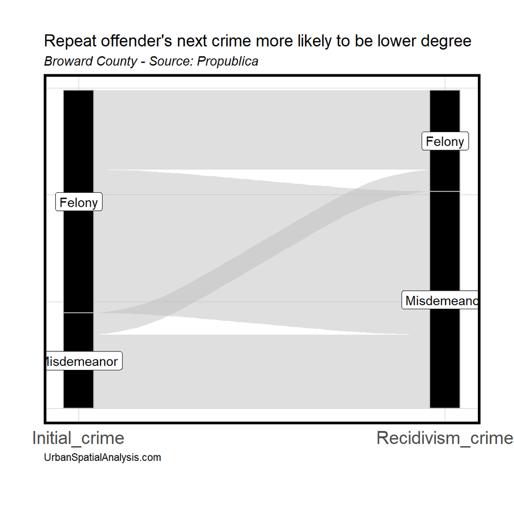

## 3. Model Building

In this section you will develop two predictive models, one with race and one without. You will do this in order to understand how the algorithm reacts to the inclusion of race as a control. There is a notion, at least among the popular press, that any inclusion of race in a model is a biasing factor. Let’s explore the extent to which that might be true in this dataset.

Given sample size limitations as evidenced by the plot, you may want to include only African American, Caucasian and Hispanic groups in your models.

```r
set.seed(336)
trainIndex <- createDataPartition(df$priors_count, p = .75,
                                    list = FALSE,
                                    times = 1)
train <- df[ trainIndex,]
test  <- df[-trainIndex,]
```

```r
set.seed(125)
reg.noRace.cv <- train(Recidivated ~ ., data = train %>%
                                               select(-race,
                                               -r_charge_degree,
                                               -r_charge_desc,
                                               -c_charge_degree,
                                               -c_charge_desc,
                                               -two_year_recid),
 family="binomial"(link="logit"), method="glm",
 metric="ROC",
 trControl = trainControl(method = "cv",number = 40,classProbs = TRUE, summaryFunction=twoClassSummary))

reg.withRace.cv <- train(Recidivated ~ ., data = train %>%
                                               select(
                                               -r_charge_degree,
                                               -r_charge_desc,
                                               -c_charge_degree,
                                               -c_charge_desc,
                                               -two_year_recid),
 family="binomial"(link="logit"), method="glm",
 metric="ROC",
 trControl = trainControl(method = "cv",number = 40,classProbs = TRUE, summaryFunction=twoClassSummary))
```

Create predicted probabilities for both regressions. Note that I use `rbind` to create a data frame that is “facet ready”. There are predicted probabilities for both the `reg.noRace.cv` and for the `reg.withRace.cv` regressions in one data frame. The `regression` field labels each which means you can `filter` on these if/when you need to access the predicted probabilities for just one regression.

This is a useful approach for storing predictions across multiple regressions. Imagine if this data frame held the predictions for 5 spatial regression models. You could then build 5 small multiple maps of residuals, predicted values, etc.

```r
testProbs <-
  rbind(
    data.frame(class = test$two_year_recid,
               probs = predict(reg.noRace.cv, test, type="prob")$Recidivate,
               predClass = ifelse(predict(reg.noRace.cv, test, type="prob")$Recidivate > .5 ,1,0),
               regression = "No Race",
               Race = test$race),
    data.frame(class = test$two_year_recid,
               probs = predict(reg.withRace.cv, test, type="prob")$Recidivate,
               predClass = ifelse(predict(reg.withRace.cv, test, type="prob")$Recidivate > .5 ,1,0),
               regression = "With Race",
               Race=test$race))

head(testProbs)
```

```
##   class     probs predClass regression             Race
## 1     1 0.7897954         1    No Race African-American
## 2     0 0.1713948         0    No Race            Other
## 3     0 0.1653939         0    No Race        Caucasian
## 4     1 0.5818442         1    No Race African-American
## 5     1 0.5647978         1    No Race African-American
## 6     1 0.2733419         0    No Race African-American
```

## 4. Evaluating accuracy

Let’s begin by analyzing accuracy. In this section we will build a number of plots and tables that try to compare across the race and no race regressions. As you read through this section, ask whether the inclusion of race is playing a role.

We build ROC curves below using a new approach. First, we create an ROC curve for the no race regression by filtering for predicted probabilities with `regression` label of `No Race`. Then we create a second ROC curve for the race regression.

Finally, we use `grid.arrange` to splice both ROC curves together.

Note how we pull the AUC score into the `title` using the `paste` function.

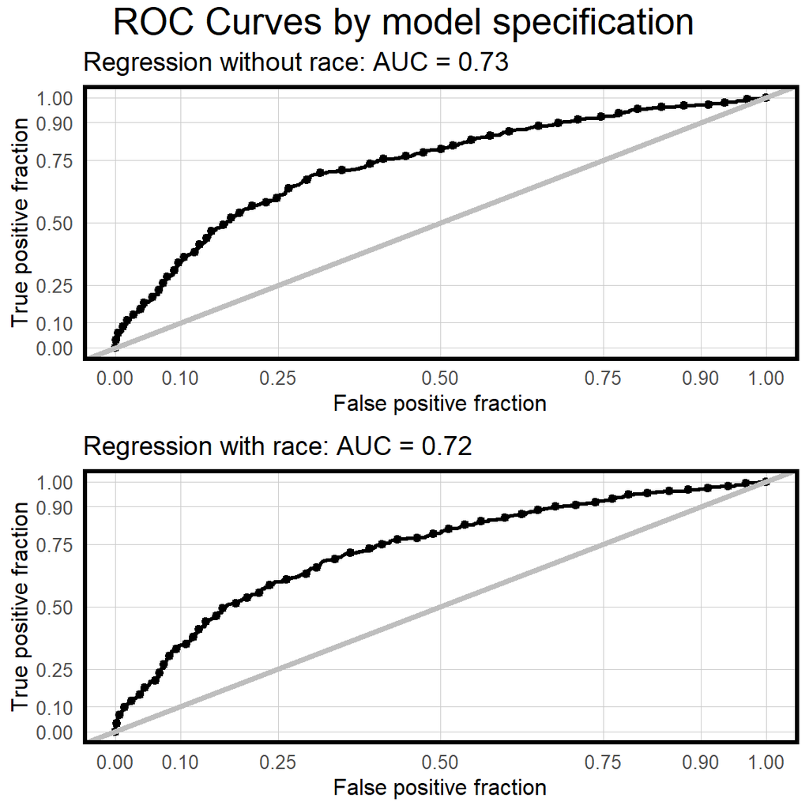

```r
roc.noRace <-
  ggplot(testProbs %>% filter(regression == "No Race"),
         aes(d = as.numeric(class), m = probs)) +
  geom_roc(n.cuts = 50, labels = FALSE) +
  style_roc(theme = theme_grey) +
  geom_abline(slope = 1, intercept = 0, size = 1.5, color = 'grey') +
  labs(title=paste("Regression without race: AUC =",
                    testProbs %>%
                     group_by(regression) %>%
                     summarize(AUC = auc(class,probs)) %>%
                     filter(regression == "No Race") %>%
                     pull(2) %>% as.character() %>% substr(.,1,4))) +
  plotTheme()

roc.withRace <-
  ggplot(testProbs %>% filter(regression == "With Race"),
         aes(d = as.numeric(class), m = probs)) +
  geom_roc(n.cuts = 50, labels = FALSE) +
  style_roc(theme = theme_grey) +
  geom_abline(slope = 1, intercept = 0, size = 1.5, color = 'grey') +
  labs(title=paste("Regression with race: AUC =",
                    testProbs %>%
                     group_by(regression) %>%
                     summarize(AUC = auc(class,probs)) %>%
                     filter(regression == "With Race") %>%
                     pull(2) %>% as.character() %>% substr(.,1,4))) +
  plotTheme()

grid.arrange(roc.noRace,roc.withRace,
  top=textGrob("ROC Curves by model specification", gp=gpar(fontsize=20)))
```

That’s a pretty plot.

**What can you conclude about these ROC curves with respect to the inclusion of race?**

Perhaps it’s reasonable to ask how accurate these models are by race type? In the code block below we `filter` for three specific races and then build two facetted plots, each with race-specific curves.

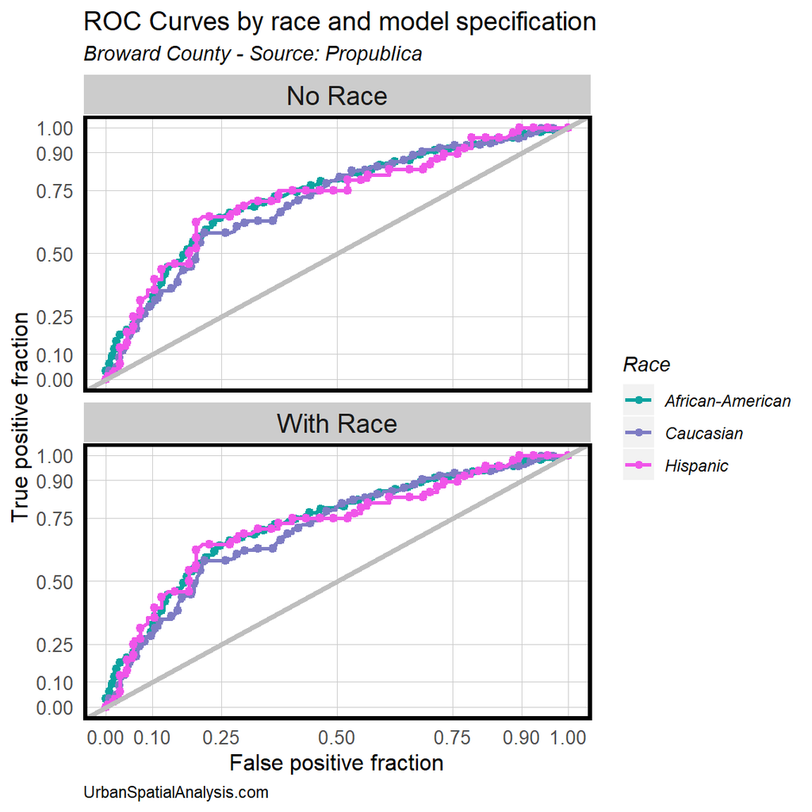

```r
ggplot(testProbs %>% filter(Race == "Caucasian" | Race == "African-American" | Race == "Hispanic"),
       aes(d = as.numeric(class), m = probs, group=Race, colour=Race)) +
  geom_roc(n.cuts = 50, labels = FALSE) +
  scale_color_manual(values = palette_3_colors) +
  style_roc(theme = theme_grey) +
  facet_wrap(~regression,ncol=1) +
  geom_abline(slope = 1, intercept = 0, size = 1.5, color = 'grey') +
  labs(title="ROC Curves by race and model specification",
       subtitle= "Broward County - Source: Propublica",
       caption="UrbanSpatialAnalysis.com") +
  plotTheme()
```

Let’s look at Auc by race across both models. How do the model accuracies differ?

```r
testProbs %>%
  group_by(regression,Race) %>%
  summarize(AUC = auc(class,probs)) %>%
  filter(Race == "African-American" | Race == "Caucasian" | Race == "Hispanic") %>%
  arrange(Race) %>%
  kable() %>%
  kable_styling("striped", full_width = F) %>%
   row_spec(c(1:2), bold = F, color = "white", background = "#0DA3A0") %>%
   row_spec(c(3:4), bold = F, color = "white", background = "#7E7CC4") %>%
   row_spec(c(5:6), bold = F, color = "white", background = "#F055E9")
```

| regression | Race | AUC |
| --- | --- | --- |
| No Race | African-American | 0.7317832 |
| With Race | African-American | 0.7320427 |
| No Race | Caucasian | 0.7090416 |
| With Race | Caucasian | 0.7089330 |
| No Race | Hispanic | 0.7252799 |
| With Race | Hispanic | 0.7234142 |

Finally, let’s take a look at observed and predicted recivism rates by regression type.

```r
testProbs %>%
  filter(Race == "Caucasian" | Race == "African-American" | Race == "Hispanic") %>%
  group_by(Race,regression) %>%
  summarize(Observed.Recidivism.Rate = sum(class) / n(),
            Predicted.Recidivism.Rate = sum(predClass) / n()) %>%
  arrange(Race) %>%
  kable() %>%
  kable_styling("striped", full_width = F) %>%
   row_spec(c(1:2), bold = F, color = "white", background = "#0DA3A0") %>%
   row_spec(c(3:4), bold = F, color = "white", background = "#7E7CC4") %>%
   row_spec(c(5:6), bold = F, color = "white", background = "#F055E9")
```

| Race | regression | Observed.Recidivism.Rate | Predicted.Recidivism.Rate |
| --- | --- | --- | --- |
| African-American | No Race | 0.4943396 | 0.5031447 |
| African-American | With Race | 0.4943396 | 0.5169811 |
| Caucasian | No Race | 0.4015444 | 0.2837838 |
| Caucasian | With Race | 0.4015444 | 0.2702703 |
| Hispanic | No Race | 0.4173913 | 0.3043478 |
| Hispanic | With Race | 0.4173913 | 0.2173913 |

Okay. Now that we’ve analyzed the accuracy of these models, we can ask some questions.

**What is the benefit of using race in the model?** **Should we institute a blanket rule, that all criminal justice predictive models be estimated without race?** **Are our models equally accurate across different racial groups?**

## 5. Evaluating bias

In this section we analyze whether our models generalize well across different racial groups. We will use the model estimated above that does not have any race in it.

First, **build a facetted barplot where the leftmost plot shows *observed* recidivism rates by race for African Americans, Whites and Hispanics. On the rightmost plot, show predictied recidivism rates by the same race groups. Interpret this plot with respect to race.**

Use `testProbs` as your input. `filter` for the needed racial groups. Use `group_by` and `summarize` to calculate rates. Check out `?ungroup` before you convert the data to long form so that you can build the facetted bar plot. There are a couple key data visualization challenges here, but probably the biggest hurdle will be going from wide to long form.

Next, we plot the confusion matrix for the three racial groups.

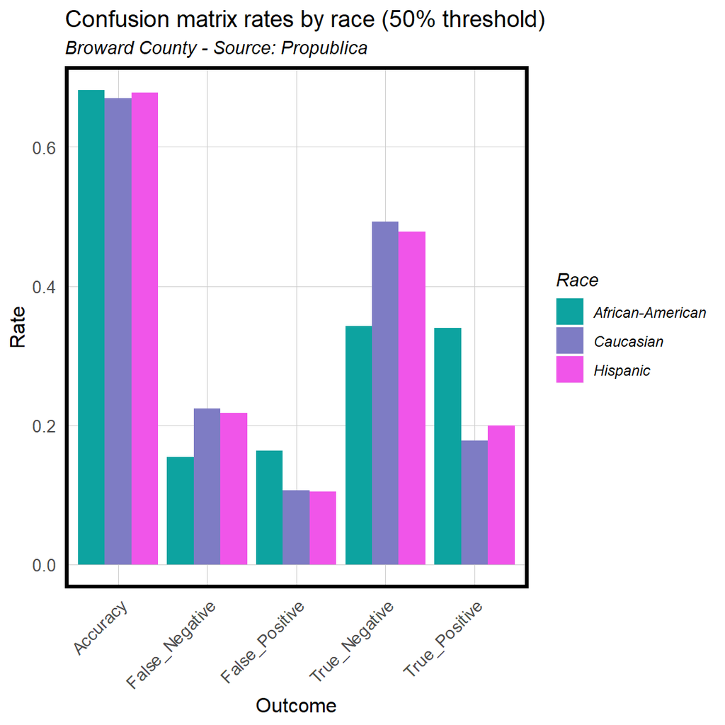

```r
testProbs %>%
  filter(Race == "Caucasian" | Race == "African-American" | Race == "Hispanic") %>%
  filter(regression == "No Race") %>%
  group_by(Race) %>%
  count(predClass,class) %>%
  summarize(sum_trueNeg = sum(n[predClass==0 & class==0]),
            sum_truePos = sum(n[predClass==1 & class==1]),
            sum_falseNeg = sum(n[predClass==0 & class==1]),
            sum_falsePos = sum(n[predClass==1 & class==0]),
            total=sum(n)) %>%
  mutate(True_Positive = sum_truePos / total,
         True_Negative = sum_trueNeg / total,
         False_Negative = sum_falseNeg / total,
         False_Positive = sum_falsePos / total,
         Accuracy = (sum_truePos + sum_trueNeg) / total) %>%
  select(Race, True_Positive, True_Negative, False_Negative, False_Positive,Accuracy) %>%
  gather(key,value,True_Positive:Accuracy) %>%
    ggplot(.,aes(key,value,fill=Race)) +
    geom_bar(aes(fill=Race),position="dodge",stat="identity") +
    scale_fill_manual(values = palette_3_colors) +
    labs(title="Confusion matrix rates by race (50% threshold)",
         subtitle = "Broward County - Source: Propublica",
         x="Outcome",y="Rate") +
    theme(axis.text.x = element_text(angle = 45, hjust = 1)) +
    plotTheme()
```

**Interpret the above plot. What should we be concerned with here? Remember who your audience is. Put it in Mayorial terms.**

Lastly, we create a table of the confusion matrix results and accuracy for the `No Race` regression.

```r
testProbs %>%
  filter(Race == "Caucasian" | Race == "African-American" | Race == "Hispanic") %>%
  filter(regression == "No Race") %>%
  group_by(Race) %>%
  count(predClass,class) %>%
  summarize(sum_trueNeg = sum(n[predClass==0 & class==0]),
         sum_truePos = sum(n[predClass==1 & class==1]),
         sum_falseNeg = sum(n[predClass==0 & class==1]),
         sum_falsePos = sum(n[predClass==1 & class==0]),
         total=sum(n)) %>%
  mutate(True_Positive = sum_truePos / total,
      True_Negative = sum_trueNeg / total,
      False_Negative = sum_falseNeg / total,
      False_Positive = sum_falsePos / total,
      Accuracy = (sum_truePos + sum_trueNeg) / total) %>%
  select(Race,True_Positive,True_Negative,False_Negative,False_Positive,Accuracy) %>%
  kable() %>%
  kable_styling("striped", full_width = F) %>%
    row_spec(c(1), bold = F, color = "white", background = "#0DA3A0") %>%
    row_spec(c(2), bold = F, color = "white", background = "#7E7CC4") %>%
    row_spec(c(3), bold = F, color = "white", background = "#F055E9")
```

| Race | True_Positive | True_Negative | False_Negative | False_Positive | Accuracy |
| --- | --- | --- | --- | --- | --- |
| African-American | 0.3396226 | 0.3421384 | 0.1547170 | 0.1635220 | 0.6817610 |
| Caucasian | 0.1776062 | 0.4922780 | 0.2239382 | 0.1061776 | 0.6698842 |
| Hispanic | 0.2000000 | 0.4782609 | 0.2173913 | 0.1043478 | 0.6782609 |

**Interpret this table. To do so, you will have to understand the context of each confusion matrix entry. Tell me about the trade-off between accuracy and generalizability as it relates the *the use* of this algorithm in prioritizing a job training program**.